# Classification Model Overview

Matt Cliff

April 15, 2018

The purpose of this paper is to provide a summary of classification methods in R. Having a good understanding of how each method expects the data set to be conditioned and how they behave with respect to *normal* or *skewed* data is a key factor in model selection.

Look forward to another composition for regression methods.

## Classification Problem

The general **Classification** (value) problem is defined as one where the observation (or outcome) variable is a discrete value. Some examples could be an outcome of *yes* or *no* or peforming character recognition on digits the outcome is one of 10 discrete values, *0* to *9*. The predictors or indepdenent variables can be either discrete or real valued (or vector valued), we are only considering the cases wiht a finite number of predictors (for non-finite we are in the theory of *Functional Analysis*)

The goal is given a set of observations and corresponding predictors in the space $\left( \mathbb{Y} \times \mathbb{X}_1 \times \dots \times \mathbb{X}_n \right)$ to come up with a candidate function *f* defined $f: \mathbb{X}_1 \times \mathbb{X}_2\times \dots \times \mathbb{X}_n\mapsto \mathbb{Y}$ that *best matches* our training data so that the function can be used to predict the outcome for future observations.

Each of the $\mathbb{X_j}$ could be discrete or continuous, we will not have any practical restriction except that they **MUST** be valued, any missing data must be dealt with prior to using this package.

## Models to consider

Do they ‘retain’ discrete attributes or convert them to real numbers?

### Linear Regression

Linear Regression using [lm](https://stat.ethz.ch/R-manual/R-devel/library/stats/html/lm.html)

Expects the input data to be linearly seperable, best way to visualize this is in two dimensions, lots of data points that are color coded red or blue and try to draw a line between them

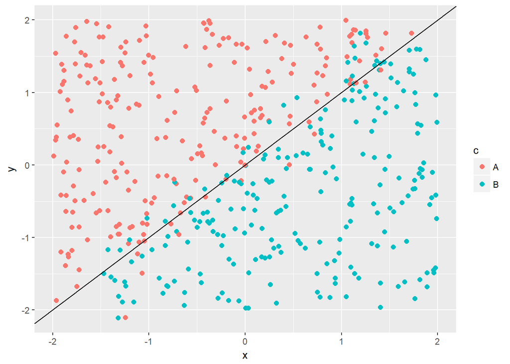

```r
num_points <- 400; noise_points = round(num_points/6)
x <- runif(num_points, min=-2, max=2)
y <- runif(num_points, min=-2, max=2)
c <- ifelse(y>x, "A", "B")
x2 <- runif(noise_points, min=-1.6, max=1.6)
y2 <- x2 + rnorm(noise_points, mean=0, sd=0.3)
c2 <- sample(c("A","B"), noise_points, replace=TRUE)

#predict_df <- data.frame(pred=predict(lm(y~x, data=demo_df), demo_df),
ggplot(data=data.frame(x=append(x,x2),y=append(y,y2),c=append(c,c2)), aes(x=x, y=y, col=c)) +
    geom_point(size=2) + geom_abline(slope = 1)
```

Solves to problem where all the spaces are fields ($\mathbb{R}$), which can lead to a large **sparse matrix**.

This translates to a problem finding the best function $f:\mathbb{R}^N \to \mathbb{R}^M$ where *M* is the number of discrete outcomes, *N* is the sum of all discrete values across all variables.

We try to find $f$ in the form of $f(x_1, x_2, \dots, x_n) = \beta_0 + \beta_1 x_1 + \beta_n x_n$ in the standard sense, or could more generally be any combination that is linear in $\beta$.

### Generalized Linear Models

Logistic Regression using [glm](http://stat.ethz.ch/R-manual/R-devel/library/stats/html/glm.html)

Expects the input data to be linearly seperable

### Linear Regression with Regularization

Lasso and Elastic-Net Regularized Generalized Linear Models

[glmnet](https://cran.r-project.org/web/packages/glmnet/glmnet.pdf) [Article](https://www.jstatsoft.org/index.php/jss/article/view/v033i01/v33i01.pdf)

### Neural Netorks [nnet](https://cran.r-project.org/web/packages/nnet/nnet.pdf)

Feed-Forward Neural Network and Multinomial Log-Linear methods Single Hidden Layer. Neural Network Data is normalized Real numbers, classifications must be converted to one-hot vectors.

nnet() key options * size - number of units in hidden layer * na.action - default is to fail; alternative is na.omit and will reject

Works on real numbers, must one-hot the space

### Support Vector Machines [svm](https://cran.r-project.org/web/packages/e1071/vignettes/svmdoc.pdf) from [e1071](https://cran.r-project.org/web/packages/e1071/e1071.pdf)

### Naive Bayes

Naive Bayes [naiveBayes](http://ugrad.stat.ubc.ca/R/library/e1071/html/naiveBayes.html) from [e1071](https://cran.r-project.org/web/packages/e1071/e1071.pdf)

### K-Nearest Neighbor

K-Nearest Neighbor [knn](http://stat.ethz.ch/R-manual/R-devel/library/class/html/knn.html)

### Decision Tree

Decision Tree [rpart](https://cran.r-project.org/web/packages/rpart/rpart.pdf)

### Ensembles of trees

Ensembles of trees [randomForest](https://cran.r-project.org/web/packages/randomForest/randomForest.pdf)

the normal *rf* method takes FOREVER.

### Generalized Boosting

Generalized Boosting [gbm](https://cran.r-project.org/web/packages/gbm/gbm.pdf)

implements Fruend and Schapire’s AdaBoost algoritm wand [Friedman’s gradient boosting machine](https://github.com/gbm-developers/gbm)

[GitHub](https://github.com/gbm-developers/gbm)

### Light Gradient Boosting Machine

[LightGBM](https://github.com/Microsoft/LightGBM/blob/master/docs/README.rst) is a gradient boosting framework that uses tree based learning algorithms Used in the Ad Tracking Kaggle Challenge; good when you have LOTS of factors (discrete values) in your predictors. Can deal with sparse matrix

[R-GitHub](https://github.com/Microsoft/LightGBM/blob/master/README.md)

Added to caret package in early 2017. [LightGBM Slack Team](https://github.com/Microsoft/LightGBM/tree/master/R-package)

[LGB Docs](https://lightgbm.readthedocs.io/en/latest/)

Parameter tunning from Kaggle Ad Tracking (notes from LGB Docs) challenge - from *lgb.train* * nrounds * early_stopping_rounds * eval_freq

From *params* * objective - binary (alias for application, some other values regression, poisson, multiclass) * metric - auc * learning rate - 0.1 (default is 0.1) * num_leaves = 7 (default 31)

### others to consider

- linear or quadratic discriminant analysis
- CART (classification and regression trees)
- Bagging

## Caret

```r
install.packages("caret", dependencies = c("Depends", "Suggests"))
```

How to [caret](https://cran.r-project.org/web/packages/caret/vignettes/caret.html)

## Evaluation Metrics for Classificaiton

ref: [machinelearning notes](https://www.machinelearningplus.com/machine-learning/evaluation-metrics-classification-models-r/)

- Confusion Matrix
- Sensitivity, Specificity and Detection Rate
- Precision, Recall, and F1 score
- Cohen’s Kappa
- KS Statistics and KS Chart
- Kolmogorov-Smirnov chart
- ROC Curve
- Concordance and Discordance
- Somers-D Statistic
- Gini Coefficient

# Specific Examples

For demonstrations, we’d like to have a mix of problems, some with valued predictors, and some with discrete, and even a mix.

## Modeling Approach

- data needs to be clean enough to have no zero elements
- first use the generic train() method from caret package to plot the mose important variables (default uses random forest)
- Random forest can tell us feature importance and when the accuracy drops off based off # of randomly selected predictors
- break data into test/training set or cross-validation set and run confusion matrix against numerous methods

### Data Analysis

Before we can decide which sort of model to use, we need to understand a little more about the data.

Are the predictors discrete or real-valued? If real-valued, is there a range or unlimited? If discrete how many different levels/values are there?

Are any predictors related to each other?

What do the density functions of each predictor look like? Anything skewed?

The basic approach will be to ensure no zero elements

```r
NAndx <- sapply(data, function(x) mean(is.na(x))) > .9
nzv <- nearZeroVar(data)
```

### Model Selection

based off the characterstics we will state which models we think will be best

#### Model Evaluation

then we evaluate the models side by side

## Specific Problems to Model

```r
trainData <- read.csv('https://raw.githubusercontent.com/selva86/datasets/master/breastcancer_training.csv')
testData <- read.csv('https://raw.githubusercontent.com/selva86/datasets/master/breastcancer_test.csv')
head(trainData)
```

```
##   Cl.thickness Cell.size Cell.shape Marg.adhesion Epith.c.size Bare.nuclei
## 1            1         1          1             1            2           1
## 2            5         1          1             1            1           1
## 3            4         1          1             1            2           1
## 4            2         1          1             1            2           1
## 5            1         2          3             1            2           1
## 6            1         2          3             1            2           1
##   Bl.cromatin Normal.nucleoli Mitoses Class
## 1           2               1       1     0
## 2           3               1       1     0
## 3           1               1       1     0
## 4           2               1       1     0
## 5           2               1       1     0
## 6           1               1       1     0
```

```r
str(trainData)
```

```
## 'data.frame':    336 obs. of  10 variables:
##  $ Cl.thickness   : int  1 5 4 2 1 1 5 5 1 4 ...
##  $ Cell.size      : int  1 1 1 1 2 2 1 1 1 1 ...
##  $ Cell.shape     : int  1 1 1 1 3 3 1 1 1 1 ...
##  $ Marg.adhesion  : int  1 1 1 1 1 1 1 1 1 1 ...
##  $ Epith.c.size   : int  2 1 2 2 2 2 2 2 2 2 ...
##  $ Bare.nuclei    : int  1 1 1 1 1 1 1 1 1 1 ...
##  $ Bl.cromatin    : int  2 3 1 2 2 1 2 3 2 2 ...
##  $ Normal.nucleoli: int  1 1 1 1 1 1 1 1 1 1 ...
##  $ Mitoses        : int  1 1 1 1 1 1 1 2 1 1 ...
##  $ Class          : int  0 0 0 0 0 0 0 0 0 0 ...
```

```r
str(testData)
```

```
## 'data.frame':    204 obs. of  10 variables:
##  $ Cl.thickness   : int  5 5 4 2 5 8 7 7 5 3 ...
##  $ Cell.size      : int  1 4 1 1 3 7 4 3 1 1 ...
##  $ Cell.shape     : int  1 4 1 2 3 5 6 2 1 1 ...
##  $ Marg.adhesion  : int  1 5 3 1 3 10 4 10 1 1 ...
##  $ Epith.c.size   : int  2 7 2 2 2 7 6 5 2 1 ...
##  $ Bare.nuclei    : int  1 10 1 1 3 9 1 10 1 1 ...
##  $ Bl.cromatin    : int  3 3 3 3 4 5 4 5 2 2 ...
##  $ Normal.nucleoli: int  1 2 1 1 4 5 3 4 1 1 ...
##  $ Mitoses        : int  1 1 1 1 1 4 1 4 1 1 ...
##  $ Class          : int  0 0 0 0 1 1 1 1 0 0 ...
```

```r
logit.mod <- glm(Class ~ Cl.thickness + Cell.size + Cell.shape, family="binomial", data=trainData)

pred <- predict(logit.mod, newdata=testData, type="response")
y_pred <- ifelse(pred > 0.5, 1, 0)

mean(y_pred == testData$Class)
```

```
## [1] 0.9411765
```

### Parkinsons Data

#### Data Analysis

These are created in Basic Data Analysis Markdown.

```r
load("data/pdData.RData")
head(pdData)
```

```
##   MDVP.Fo.Hz. MDVP.Fhi.Hz. MDVP.Flo.Hz. MDVP.Jitter... MDVP.Jitter.Abs.
## 1     119.992      157.302       74.997        0.00784          0.00007
## 2     122.400      148.650      113.819        0.00968          0.00008
## 3     116.682      131.111      111.555        0.01050          0.00009
## 4     116.676      137.871      111.366        0.00997          0.00009
## 5     116.014      141.781      110.655        0.01284          0.00011
## 6     120.552      131.162      113.787        0.00968          0.00008
##   MDVP.RAP MDVP.PPQ Jitter.DDP MDVP.Shimmer MDVP.Shimmer.dB. Shimmer.APQ3
## 1  0.00370  0.00554    0.01109      0.04374            0.426      0.02182
## 2  0.00465  0.00696    0.01394      0.06134            0.626      0.03134
## 3  0.00544  0.00781    0.01633      0.05233            0.482      0.02757
## 4  0.00502  0.00698    0.01505      0.05492            0.517      0.02924
## 5  0.00655  0.00908    0.01966      0.06425            0.584      0.03490
## 6  0.00463  0.00750    0.01388      0.04701            0.456      0.02328
##   Shimmer.APQ5 MDVP.APQ Shimmer.DDA     NHR    HNR status     RPDE
## 1      0.03130  0.02971     0.06545 0.02211 21.033      1 0.414783
## 2      0.04518  0.04368     0.09403 0.01929 19.085      1 0.458359
## 3      0.03858  0.03590     0.08270 0.01309 20.651      1 0.429895
## 4      0.04005  0.03772     0.08771 0.01353 20.644      1 0.434969
## 5      0.04825  0.04465     0.10470 0.01767 19.649      1 0.417356
## 6      0.03526  0.03243     0.06985 0.01222 21.378      1 0.415564
##        DFA   spread1  spread2       D2      PPE
## 1 0.815285 -4.813031 0.266482 2.301442 0.284654
## 2 0.819521 -4.075192 0.335590 2.486855 0.368674
## 3 0.825288 -4.443179 0.311173 2.342259 0.332634
## 4 0.819235 -4.117501 0.334147 2.405554 0.368975
## 5 0.823484 -3.747787 0.234513 2.332180 0.410335
## 6 0.825069 -4.242867 0.299111 2.187560 0.357775
```

```r
str(pdData)
```

```
## 'data.frame':    195 obs. of  23 variables:
##  $ MDVP.Fo.Hz.     : num  120 122 117 117 116 ...
##  $ MDVP.Fhi.Hz.    : num  157 149 131 138 142 ...
##  $ MDVP.Flo.Hz.    : num  75 114 112 111 111 ...
##  $ MDVP.Jitter...  : num  0.00784 0.00968 0.0105 0.00997 0.01284 ...
##  $ MDVP.Jitter.Abs.: num  0.00007 0.00008 0.00009 0.00009 0.00011 0.00008 0.00003 0.00003 0.00006 0.00006 ...
##  $ MDVP.RAP        : num  0.0037 0.00465 0.00544 0.00502 0.00655 0.00463 0.00155 0.00144 0.00293 0.00268 ...
##  $ MDVP.PPQ        : num  0.00554 0.00696 0.00781 0.00698 0.00908 0.0075 0.00202 0.00182 0.00332 0.00332 ...
##  $ Jitter.DDP      : num  0.0111 0.0139 0.0163 0.015 0.0197 ...
##  $ MDVP.Shimmer    : num  0.0437 0.0613 0.0523 0.0549 0.0643 ...
##  $ MDVP.Shimmer.dB.: num  0.426 0.626 0.482 0.517 0.584 0.456 0.14 0.134 0.191 0.255 ...
##  $ Shimmer.APQ3    : num  0.0218 0.0313 0.0276 0.0292 0.0349 ...
##  $ Shimmer.APQ5    : num  0.0313 0.0452 0.0386 0.0401 0.0483 ...
##  $ MDVP.APQ        : num  0.0297 0.0437 0.0359 0.0377 0.0447 ...
##  $ Shimmer.DDA     : num  0.0654 0.094 0.0827 0.0877 0.1047 ...
##  $ NHR             : num  0.0221 0.0193 0.0131 0.0135 0.0177 ...
##  $ HNR             : num  21 19.1 20.7 20.6 19.6 ...
##  $ status          : Factor w/ 2 levels "0","1": 2 2 2 2 2 2 2 2 2 2 ...
##  $ RPDE            : num  0.415 0.458 0.43 0.435 0.417 ...
##  $ DFA             : num  0.815 0.82 0.825 0.819 0.823 ...
##  $ spread1         : num  -4.81 -4.08 -4.44 -4.12 -3.75 ...
##  $ spread2         : num  0.266 0.336 0.311 0.334 0.235 ...
##  $ D2              : num  2.3 2.49 2.34 2.41 2.33 ...
##  $ PPE             : num  0.285 0.369 0.333 0.369 0.41 ...
```

```r
summary(pdData)
```

```
##   MDVP.Fo.Hz.      MDVP.Fhi.Hz.    MDVP.Flo.Hz.    MDVP.Jitter...
##  Min.   : 88.33   Min.   :102.1   Min.   : 65.48   Min.   :0.001680
##  1st Qu.:117.57   1st Qu.:134.9   1st Qu.: 84.29   1st Qu.:0.003460
##  Median :148.79   Median :175.8   Median :104.31   Median :0.004940
##  Mean   :154.23   Mean   :197.1   Mean   :116.32   Mean   :0.006220
##  3rd Qu.:182.77   3rd Qu.:224.2   3rd Qu.:140.02   3rd Qu.:0.007365
##  Max.   :260.11   Max.   :592.0   Max.   :239.17   Max.   :0.033160
##  MDVP.Jitter.Abs.       MDVP.RAP           MDVP.PPQ
##  Min.   :7.000e-06   Min.   :0.000680   Min.   :0.000920
##  1st Qu.:2.000e-05   1st Qu.:0.001660   1st Qu.:0.001860
##  Median :3.000e-05   Median :0.002500   Median :0.002690
##  Mean   :4.396e-05   Mean   :0.003306   Mean   :0.003446
##  3rd Qu.:6.000e-05   3rd Qu.:0.003835   3rd Qu.:0.003955
##  Max.   :2.600e-04   Max.   :0.021440   Max.   :0.019580
##    Jitter.DDP        MDVP.Shimmer     MDVP.Shimmer.dB.  Shimmer.APQ3
##  Min.   :0.002040   Min.   :0.00954   Min.   :0.0850   Min.   :0.004550
##  1st Qu.:0.004985   1st Qu.:0.01650   1st Qu.:0.1485   1st Qu.:0.008245
##  Median :0.007490   Median :0.02297   Median :0.2210   Median :0.012790
##  Mean   :0.009920   Mean   :0.02971   Mean   :0.2823   Mean   :0.015664
##  3rd Qu.:0.011505   3rd Qu.:0.03789   3rd Qu.:0.3500   3rd Qu.:0.020265
##  Max.   :0.064330   Max.   :0.11908   Max.   :1.3020   Max.   :0.056470
##   Shimmer.APQ5        MDVP.APQ        Shimmer.DDA           NHR
##  Min.   :0.00570   Min.   :0.00719   Min.   :0.01364   Min.   :0.000650
##  1st Qu.:0.00958   1st Qu.:0.01308   1st Qu.:0.02474   1st Qu.:0.005925
##  Median :0.01347   Median :0.01826   Median :0.03836   Median :0.011660
##  Mean   :0.01788   Mean   :0.02408   Mean   :0.04699   Mean   :0.024847
##  3rd Qu.:0.02238   3rd Qu.:0.02940   3rd Qu.:0.06080   3rd Qu.:0.025640
##  Max.   :0.07940   Max.   :0.13778   Max.   :0.16942   Max.   :0.314820
##       HNR         status       RPDE             DFA
##  Min.   : 8.441   0: 48   Min.   :0.2566   Min.   :0.5743
##  1st Qu.:19.198   1:147   1st Qu.:0.4213   1st Qu.:0.6748
##  Median :22.085           Median :0.4960   Median :0.7223
##  Mean   :21.886           Mean   :0.4985   Mean   :0.7181
##  3rd Qu.:25.076           3rd Qu.:0.5876   3rd Qu.:0.7619
##  Max.   :33.047           Max.   :0.6852   Max.   :0.8253
##     spread1          spread2               D2             PPE
##  Min.   :-7.965   Min.   :0.006274   Min.   :1.423   Min.   :0.04454
##  1st Qu.:-6.450   1st Qu.:0.174350   1st Qu.:2.099   1st Qu.:0.13745
##  Median :-5.721   Median :0.218885   Median :2.362   Median :0.19405
##  Mean   :-5.684   Mean   :0.226510   Mean   :2.382   Mean   :0.20655
##  3rd Qu.:-5.046   3rd Qu.:0.279234   3rd Qu.:2.636   3rd Qu.:0.25298
##  Max.   :-2.434   Max.   :0.450493   Max.   :3.671   Max.   :0.52737
```

```r
#table(as.factor(pdData$status))
```

Notice the status field on the summary output show 48 with status **0** - negative for PD and 147 with status **1** - has PD (total of **195** observations)

Observation is **status** and has two values, making this a binomial classification problem.

There are 22 predictors that are all continuous valued.

Now let’s pull out a training and test set and see what kind of predictions we can make with this

```r
set.seed(45278)
inTrain <- createDataPartition(pdData$status, p=0.7, list=FALSE)
training <- pdData[inTrain,]
testing <- pdData[-inTrain,]
table(training$status)
```

```
##
##   0   1
##  34 103
```

```r
control <- trainControl(method="cv", number=4, allowParallel=TRUE)


#preproc <- preProcess(select(training,-(status)), method=c("center", "scale", "pca"), thresh = 0.8)
preproc <- preProcess(select(training,-(status)), method="pca", thresh = 0.8)

# TODO - I couldn't load these earlier or we failed
library(mda) #mda
library(MASS) #qda
```

#### Model Selection

Experiment with different models

**TODO:**

- Linear not working
- GBM not working
- FDA not working
- RDA not working

##### Linear Regression

This model is throwing an error about factors not allowed; thing I need to convert the data to 1-hot type of loading

```r
# error: factors are not allows Calls
fit.lm <- lm(status ~ ., data=training)
summary(fit.lm)
predict.mda <- predict(fit.lm, newdata=testing)
table(predict.lm, testing$status)
```

##### Logistic Regression

```r
set.seed(10)

#fit.glm <- glm(status ~ ., data=training)
#summary(fit.glm)
#predict.glm <- predict(fit.glm, newdata=testing)
#table(predict.glm, testing$status)

tic("glm")
fit.glm <- train(status ~ ., data=training, method="glm", preProcess="pca", trControl = control)
t_out <- toc()
```

```
## glm: 0.83 sec elapsed
```

```r
#print(t_out) # use this later when summarizing reults
predict.glm <- predict(fit.glm, newdata=testing)
confMat.glm <- confusionMatrix(predict.glm, testing$status)
confMat.glm
```

```
## Confusion Matrix and Statistics
##
##           Reference
## Prediction  0  1
##          0  9  3
##          1  5 41
##
##                Accuracy : 0.8621
##                  95% CI : (0.7462, 0.9385)
##     No Information Rate : 0.7586
##     P-Value [Acc > NIR] : 0.03995
##
##                   Kappa : 0.6041
##  Mcnemar's Test P-Value : 0.72367
##
##             Sensitivity : 0.6429
##             Specificity : 0.9318
##          Pos Pred Value : 0.7500
##          Neg Pred Value : 0.8913
##              Prevalence : 0.2414
##          Detection Rate : 0.1552
##    Detection Prevalence : 0.2069
##       Balanced Accuracy : 0.7873
##
##        'Positive' Class : 0
##
```

```r
tic("glm without pca preprocessing")
fit.glm <- train(status ~ ., data=training, method="glm", trControl = control)
t_out <- toc()
```

```
## glm without pca preprocessing: 0.72 sec elapsed
```

```r
#print(t_out) # use this later when summarizing reults
predict.glm <- predict(fit.glm, newdata=testing)
confMat.glm <- confusionMatrix(predict.glm, testing$status)
confMat.glm
```

```
## Confusion Matrix and Statistics
##
##           Reference
## Prediction  0  1
##          0  9  7
##          1  5 37
##
##                Accuracy : 0.7931
##                  95% CI : (0.6665, 0.8883)
##     No Information Rate : 0.7586
##     P-Value [Acc > NIR] : 0.3305
##
##                   Kappa : 0.4613
##  Mcnemar's Test P-Value : 0.7728
##
##             Sensitivity : 0.6429
##             Specificity : 0.8409
##          Pos Pred Value : 0.5625
##          Neg Pred Value : 0.8810
##              Prevalence : 0.2414
##          Detection Rate : 0.1552
##    Detection Prevalence : 0.2759
##       Balanced Accuracy : 0.7419
##
##        'Positive' Class : 0
##
```

##### Regression with Regularization

```r
set.seed(10)
suppressMessages(library(glmnet))




fit.glmnet <- train(status ~ ., data=training, method="glmnet", preProcess="pca", trControl = control)

predict.glmnet <- predict(fit.glmnet, newdata=testing)


confMat.glmnet <- confusionMatrix(predict.glmnet, testing$status)
names(confMat.glmnet)
```

```
## [1] "positive" "table"    "overall"  "byClass"  "mode"     "dots"
```

```r
confMat.glmnet
```

```
## Confusion Matrix and Statistics
##
##           Reference
## Prediction  0  1
##          0  7  1
##          1  7 43
##
##                Accuracy : 0.8621
##                  95% CI : (0.7462, 0.9385)
##     No Information Rate : 0.7586
##     P-Value [Acc > NIR] : 0.03995
##
##                   Kappa : 0.5589
##  Mcnemar's Test P-Value : 0.07710
##
##             Sensitivity : 0.5000
##             Specificity : 0.9773
##          Pos Pred Value : 0.8750
##          Neg Pred Value : 0.8600
##              Prevalence : 0.2414
##          Detection Rate : 0.1207
##    Detection Prevalence : 0.1379
##       Balanced Accuracy : 0.7386
##
##        'Positive' Class : 0
##
```

##### Neural Network

Neural Net does not seem to work at all; predicts that everything is true.

```r
library(nnet)
tic("nnet")
fit.nnet <- nnet(status ~ ., data=training, size=4, decay=0.0001, maxit=500, trace=FALSE)
toc()
```

```
## nnet: 0 sec elapsed
```

```r
#summary(fit.nnet)
predict.nnet <- predict(fit.nnet, newdata=testing, type="class")
table(predict.nnet, testing$status)
```

```
##
## predict.nnet  0  1
##            1 14 44
```

```r
#confMat.nnet <- confusionMatrix(predict.nnet, testing$status)
#confMat.nnet
```

Looks like this is all showing positive (**1**) outcomes

##### Support Vector Machine

This is a good model to determine linear seperability

classification for multiple class is supported by a one-vs-all method.

```r
suppressMessages(library(kernlab))
tic("svm")
fit.ksvm <- ksvm(status ~ ., data=training)
toc()
```

```
## svm: 0 sec elapsed
```

```r
#summary(fit.ksvm)
predict.ksvm <- predict(fit.ksvm, newdata=testing, type="response")
#table(predict.ksvm, testing$status)
confMat.ksvm <- confusionMatrix(predict.ksvm, testing$status)
confMat.ksvm
```

```
## Confusion Matrix and Statistics
##
##           Reference
## Prediction  0  1
##          0  8  0
##          1  6 44
##
##                Accuracy : 0.8966
##                  95% CI : (0.7883, 0.9611)
##     No Information Rate : 0.7586
##     P-Value [Acc > NIR] : 0.006873
##
##                   Kappa : 0.6692
##  Mcnemar's Test P-Value : 0.041227
##
##             Sensitivity : 0.5714
##             Specificity : 1.0000
##          Pos Pred Value : 1.0000
##          Neg Pred Value : 0.8800
##              Prevalence : 0.2414
##          Detection Rate : 0.1379
##    Detection Prevalence : 0.1379
##       Balanced Accuracy : 0.7857
##
##        'Positive' Class : 0
##
```

##### Naive Bayes

```r
tic("nb")
fit.nb <- naiveBayes(status ~ ., data=training)
toc()
```

```
## nb: 0.02 sec elapsed
```

```r
#summary(fit.nb)
predict.nb <- predict(fit.nb, newdata=testing)
#table(predict.nb, testing$status)
confMat.nb <- confusionMatrix(predict.nb, testing$status)
confMat.nb
```

```
## Confusion Matrix and Statistics
##
##           Reference
## Prediction  0  1
##          0 13 17
##          1  1 27
##
##                Accuracy : 0.6897
##                  95% CI : (0.5546, 0.8046)
##     No Information Rate : 0.7586
##     P-Value [Acc > NIR] : 0.913329
##
##                   Kappa : 0.3902
##  Mcnemar's Test P-Value : 0.000407
##
##             Sensitivity : 0.9286
##             Specificity : 0.6136
##          Pos Pred Value : 0.4333
##          Neg Pred Value : 0.9643
##              Prevalence : 0.2414
##          Detection Rate : 0.2241
##    Detection Prevalence : 0.5172
##       Balanced Accuracy : 0.7711
##
##        'Positive' Class : 0
##
```

##### K-NN

Let’s move this to a new line to see what the deal is

```r
# error that object type 'closure' is not subsettable
#fit.knn <- knn3(status ~ ., data=training, k=5)

#set.seed(10)
fit.knn <- train(status ~ ., data=training, method="knn", trControl = control)


#summary(knn)
#predict.knn <- predict(fit.knn, newdata=testing, type="class")
#table(predict.knn, testing$status)

predict.knn <- predict(fit.knn, newdata=testing)
confMat.knn <- confusionMatrix(predict.knn, testing$status)
confMat.knn
```

```
## Confusion Matrix and Statistics
##
##           Reference
## Prediction  0  1
##          0  5  1
##          1  9 43
##
##                Accuracy : 0.8276
##                  95% CI : (0.7057, 0.9141)
##     No Information Rate : 0.7586
##     P-Value [Acc > NIR] : 0.14015
##
##                   Kappa : 0.4153
##  Mcnemar's Test P-Value : 0.02686
##
##             Sensitivity : 0.35714
##             Specificity : 0.97727
##          Pos Pred Value : 0.83333
##          Neg Pred Value : 0.82692
##              Prevalence : 0.24138
##          Detection Rate : 0.08621
##    Detection Prevalence : 0.10345
##       Balanced Accuracy : 0.66721
##
##        'Positive' Class : 0
##
```

##### Decision Tree

```r
set.seed(10)
tic("rpart")
fit.rpart <- train(status ~ ., data=training, method="rpart", trControl=control)
toc()
```

```
## rpart: 0.37 sec elapsed
```

```r
#summary(fit.rpart)
predict.rpart <- predict(fit.rpart, newdata=testing)
#table(predict.rpart, testing$status)


confMat.rpart <- confusionMatrix(predict.rpart, testing$status)
#confMat.rpart$overall
confMat.rpart
```

```
## Confusion Matrix and Statistics
##
##           Reference
## Prediction  0  1
##          0 10  2
##          1  4 42
##
##                Accuracy : 0.8966
##                  95% CI : (0.7883, 0.9611)
##     No Information Rate : 0.7586
##     P-Value [Acc > NIR] : 0.006873
##
##                   Kappa : 0.7031
##  Mcnemar's Test P-Value : 0.683091
##
##             Sensitivity : 0.7143
##             Specificity : 0.9545
##          Pos Pred Value : 0.8333
##          Neg Pred Value : 0.9130
##              Prevalence : 0.2414
##          Detection Rate : 0.1724
##    Detection Prevalence : 0.2069
##       Balanced Accuracy : 0.8344
##
##        'Positive' Class : 0
##
```

##### Random Forest

Random Forest is the default method for the *caret* package **train** method.

TODO add method *randomForest()* as well

```r
set.seed(10)
tic("rf")
fit.rf <- train(status ~ ., data=training, method="rf", trControl=control)
toc()
```

```
## rf: 0.95 sec elapsed
```

```r
#summary(fit.rf)
predict.rf <- predict(fit.rf, newdata=testing)
#table(predict.rf, testing$status)

confMat.rf <- confusionMatrix(predict.rf, testing$status)
#confMat.rf$overall
confMat.rf
```

```
## Confusion Matrix and Statistics
##
##           Reference
## Prediction  0  1
##          0 10  1
##          1  4 43
##
##                Accuracy : 0.9138
##                  95% CI : (0.8102, 0.9714)
##     No Information Rate : 0.7586
##     P-Value [Acc > NIR] : 0.002252
##
##                   Kappa : 0.7461
##  Mcnemar's Test P-Value : 0.371093
##
##             Sensitivity : 0.7143
##             Specificity : 0.9773
##          Pos Pred Value : 0.9091
##          Neg Pred Value : 0.9149
##              Prevalence : 0.2414
##          Detection Rate : 0.1724
##    Detection Prevalence : 0.1897
##       Balanced Accuracy : 0.8458
##
##        'Positive' Class : 0
##
```

this section was in a data exploration section, but is really using randomForest model

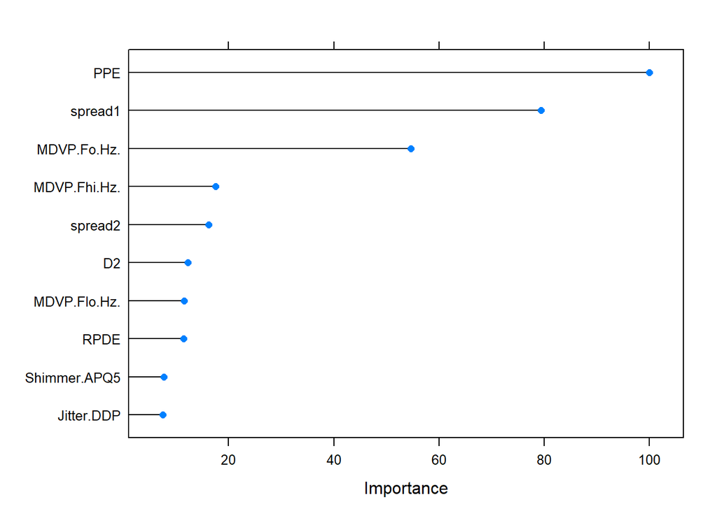

```r
pdFit <- train(status ~ ., data=pdData)
plot(varImp(pdFit, varImp.train=FALSE), top=10)
```

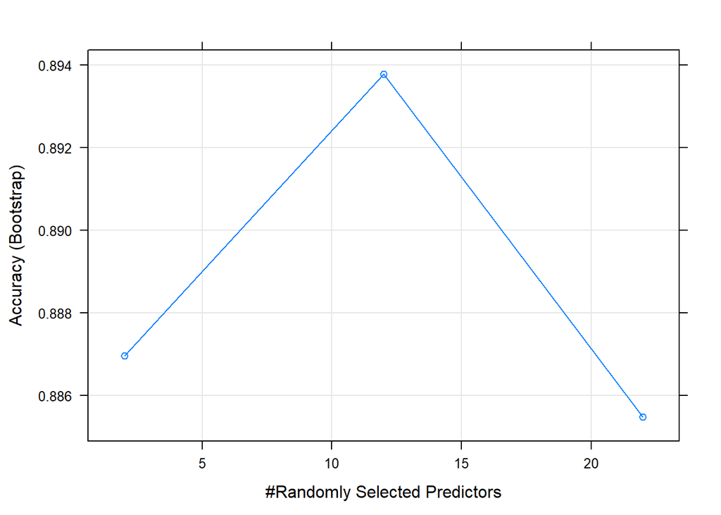

```r
#summary(pdFit)
plot(pdFit)
```

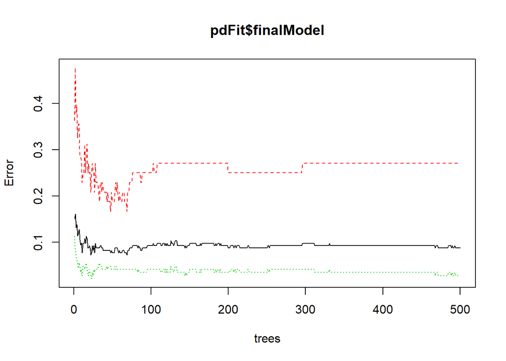

```r
plot(pdFit$finalModel)
```

```r
pdFit$finalModel
```

```
##
## Call:
##  randomForest(x = x, y = y, mtry = param$mtry)
##                Type of random forest: classification
##                      Number of trees: 500
## No. of variables tried at each split: 12
##
##         OOB estimate of  error rate: 8.72%
## Confusion matrix:
##    0   1 class.error
## 0 35  13  0.27083333
## 1  4 143  0.02721088
```

##### Gradient Boosting

Eval is set to False

```r
library(gbm)
fit.gbm <- gbm(status ~ ., data=training)
#summary(fit.gbm)
predict.gbm <- predict(fit.gbm, newdata=testing)
table(predict.gbm, testing$status)
confMat.gbm <- confusionMatrix(predict.gbm, testing$status)
confMat.gbm
```

##### Mixture Discriminatnt Analysis

```r
tic("mda")
fit.mda <- mda(status ~ ., data=training)
toc()
```

```
## mda: 0.12 sec elapsed
```

```r
#summary(fit.mda)
predict.mda <- predict(fit.mda, newdata=testing)
#table(predict.mda, testing$status)
confMat.mda <- confusionMatrix(predict.mda, testing$status)
confMat.mda
```

```
## Confusion Matrix and Statistics
##
##           Reference
## Prediction  0  1
##          0  8  4
##          1  6 40
##
##                Accuracy : 0.8276
##                  95% CI : (0.7057, 0.9141)
##     No Information Rate : 0.7586
##     P-Value [Acc > NIR] : 0.1402
##
##                   Kappa : 0.5051
##  Mcnemar's Test P-Value : 0.7518
##
##             Sensitivity : 0.5714
##             Specificity : 0.9091
##          Pos Pred Value : 0.6667
##          Neg Pred Value : 0.8696
##              Prevalence : 0.2414
##          Detection Rate : 0.1379
##    Detection Prevalence : 0.2069
##       Balanced Accuracy : 0.7403
##
##        'Positive' Class : 0
##
```

##### Quadratic Discriminant Analysis

maximize the distance between the classes

```r
tic("qda")
fit.qda <- qda(status ~ ., data=training)
toc()
```

```
## qda: 0 sec elapsed
```

```r
#summary(fit.qda)
predict.qda <- predict(fit.qda, newdata=testing)$class
confMat.qda <- confusionMatrix(predict.qda, testing$status)
confMat.qda
```

```
## Confusion Matrix and Statistics
##
##           Reference
## Prediction  0  1
##          0  7  1
##          1  7 43
##
##                Accuracy : 0.8621
##                  95% CI : (0.7462, 0.9385)
##     No Information Rate : 0.7586
##     P-Value [Acc > NIR] : 0.03995
##
##                   Kappa : 0.5589
##  Mcnemar's Test P-Value : 0.07710
##
##             Sensitivity : 0.5000
##             Specificity : 0.9773
##          Pos Pred Value : 0.8750
##          Neg Pred Value : 0.8600
##              Prevalence : 0.2414
##          Detection Rate : 0.1207
##    Detection Prevalence : 0.1379
##       Balanced Accuracy : 0.7386
##
##        'Positive' Class : 0
##
```

##### Regularized Discriminant Analysis

```r
library(klaR)
tic("rda")
fit.rda <- rda(status ~ ., data=training, gamma=0.05, lambda=0.01)
toc()
```

```
## rda: 0.02 sec elapsed
```

```r
#summary(fit.rda)
predict.rda <- predict(fit.rda, newdata=testing)$class
head(predict.rda)
```

```
## [1] 1 1 1 1 1 1
## Levels: 0 1
```

```r
# getting error about all arguements must have same length on table
#table(predict.rda, testing$status)
confMat.rda <- confusionMatrix(predict.rda, testing$status)
confMat.rda
```

```
## Confusion Matrix and Statistics
##
##           Reference
## Prediction  0  1
##          0  0  0
##          1 14 44
##
##                Accuracy : 0.7586
##                  95% CI : (0.6283, 0.8613)
##     No Information Rate : 0.7586
##     P-Value [Acc > NIR] : 0.571112
##
##                   Kappa : 0
##  Mcnemar's Test P-Value : 0.000512
##
##             Sensitivity : 0.0000
##             Specificity : 1.0000
##          Pos Pred Value :    NaN
##          Neg Pred Value : 0.7586
##              Prevalence : 0.2414
##          Detection Rate : 0.0000
##    Detection Prevalence : 0.0000
##       Balanced Accuracy : 0.5000
##
##        'Positive' Class : 0
##
```

##### Flexible Discriminant Analysis

```r
tic("fda")
fit.fda <- fda(status ~ ., data=training)
toc()
# get error that 'x' must be actomic (changed to eval=FALSE)
summary(fit.fda)
predict.fda <- predict(fit.qda, newdata=testing)
table(predict.fda, testing$status)
confMat.fda <- confusionMatrix(predict.fda, testing$status)
confMat.fda
```

##### other

this was up in the top, but never used

Check out this [Kaggle LGB](https://www.kaggle.com/pranav84/talkingdata-eda-to-model-evaluation-lb-0-9683)

LightGBM offers good accuracy when using native categorical features instead of one-hot coding. As per the official documentation dated [22nd March 2018](https://media.readthedocs.org/pdf/lightgbm/latest/lightgbm.pdf), LightGBM can find the optimal split of categorical features. Such an optimal split can provide the much better accuracy than one-hot coding solution.

```r
xgbTreeGrid <- expand.grid(nrounds=400, max_depth=3, eta=0.1,
                           gamma = 0,
                           colsample_bytree = 1.0,
                           subsample = 1.0,
                           min_child_weight = 4)

glmGrid <- expand.grid(.alpha = 1, .lambda=seq(0.001,0.1, by=0.001))

#modelList <- caretList(
#    status ~ ., data=training, trControl=control,
#    tuneList = list(
#        xgbTree = caretModelSpec(method="xgbTree", tuneGrid = xgbTreeGrid, nthread=8),
#        glmnet = caretModelSpec(method="glm", tuneGrid=glmGrid)
#    )
#)
```

#### Model Evaluation

This section should be a summary of the results above, there shouldn’t be new calculations here

```r
results <- resamples(list(glm=fit.glm,
                          knn=fit.knn,
#                          glmnet=fit.glmnet,
#                          nnet=fit.nnet,
#                          svm=fit.ksvm,
#                          nb=fit.nb,
                          rpart=fit.rpart,
                          rf=fit.rf))
#                          mda=fit.mda,
#                          qda=fit.qda,
#                          rda=fit.rda))


summary(results)
```

```
##
## Call:
## summary.resamples(object = results)
##
## Models: glm, knn, rpart, rf
## Number of resamples: 4
##
## Accuracy
##            Min.   1st Qu.    Median      Mean   3rd Qu.      Max. NA's
## glm   0.7352941 0.7573529 0.7794118 0.7806723 0.8027311 0.8285714    0
## knn   0.7647059 0.7820856 0.8082251 0.8095747 0.8357143 0.8571429    0
## rpart 0.7142857 0.7741597 0.8088235 0.7962185 0.8308824 0.8529412    0
## rf    0.8285714 0.8909664 0.9117647 0.8909664 0.9117647 0.9117647    0
##
## Kappa
##            Min.   1st Qu.    Median      Mean   3rd Qu.      Max. NA's
## glm   0.2311558 0.4184760 0.5015022 0.4463606 0.5293868 0.5512821    0
## knn   0.1168831 0.3637532 0.4605216 0.3952518 0.4920202 0.5430809    0
## rpart 0.1935484 0.3536197 0.4502969 0.4178141 0.5144914 0.5771144    0
## rf    0.4750000 0.6574240 0.7309753 0.6754819 0.7490332 0.7649770    0
```

```r
accuracy <- data.frame(
    glm=confMat.glm$overall[1],
    knn=confMat.knn$overall[1],
    glmnet=confMat.glmnet$overall[1],
    #nnet=confMat.nnet$overall[1],
    ksvm=confMat.ksvm$overall[1],
    nb=confMat.nb$overall[1],
    rf=confMat.rf$overall[1],
    mda=confMat.mda$overall[1],
    qda=confMat.qda$overall[1],
    rda=confMat.rda$overall[1]
)
accuracy
```

```
##                glm       knn   glmnet      ksvm        nb        rf
## Accuracy 0.7931034 0.8275862 0.862069 0.8965517 0.6896552 0.9137931
##                mda      qda       rda
## Accuracy 0.8275862 0.862069 0.7586207
```

Move these predictions up above

```r
performance <- matrix(round(c(confMat.rf$overall, confMat.knn$overall, confMat.glm$overall), 3), ncol=3)
colnames(performance) <- c('Random Forest', 'K-Nearest Neighbors', 'GLM pca')
#rownames(performance) <- c('Accuracy', 'Kappa', 'AccuracyLower', 'AccuracyUpper', 'AccuracyNull', 'AccuracyPValue', 'McnemarPValue')
rownames(performance) <- rownames(confMat.rf$overall)
print(as.table(performance))
```

```
##   Random Forest K-Nearest Neighbors GLM pca
## A         0.914               0.828   0.793
## B         0.746               0.415   0.461
## C         0.810               0.706   0.666
## D         0.971               0.914   0.888
## E         0.759               0.759   0.759
## F         0.002               0.140   0.331
## G         0.371               0.027   0.773
```

Lastly try using caretEnsamble

### Buzz in Social Media

[Buzz in Social Media](https://archive.ics.uci.edu/ml/datasets/Buzz+in+social+media+)

### Sensorless Drive

[Sensorless drive](https://archive.ics.uci.edu/ml/datasets/Dataset+for+Sensorless+Drive+Diagnosis) - 49 attributes, 11 classes, 58000 records

### Card Payments (Binary Classifier)

[card payment](https://archive.ics.uci.edu/ml/datasets/default+of+credit+card+clients) binary classifier with 23 predictors

```r
load("data/ccData.RData")
head(ccData)
```

```
##   LIMIT_BAL SEX EDUCATION MARRIAGE AGE PAY_0 PAY_2 PAY_3 PAY_4 PAY_5 PAY_6
## 1     20000   2         2        1  24     2     2    -1    -1    -2    -2
## 2    120000   2         2        2  26    -1     2     0     0     0     2
## 3     90000   2         2        2  34     0     0     0     0     0     0
## 4     50000   2         2        1  37     0     0     0     0     0     0
## 5     50000   1         2        1  57    -1     0    -1     0     0     0
## 6     50000   1         1        2  37     0     0     0     0     0     0
##   BILL_AMT1 BILL_AMT2 BILL_AMT3 BILL_AMT4 BILL_AMT5 BILL_AMT6 PAY_AMT1
## 1      3913      3102       689         0         0         0        0
## 2      2682      1725      2682      3272      3455      3261        0
## 3     29239     14027     13559     14331     14948     15549     1518
## 4     46990     48233     49291     28314     28959     29547     2000
## 5      8617      5670     35835     20940     19146     19131     2000
## 6     64400     57069     57608     19394     19619     20024     2500
##   PAY_AMT2 PAY_AMT3 PAY_AMT4 PAY_AMT5 PAY_AMT6 default.payment.next.month
## 1      689        0        0        0        0                          1
## 2     1000     1000     1000        0     2000                          1
## 3     1500     1000     1000     1000     5000                          0
## 4     2019     1200     1100     1069     1000                          0
## 5    36681    10000     9000      689      679                          0
## 6     1815      657     1000     1000      800                          0
```

## References

- [UCI Datasets](https://archive.ics.uci.edu/ml/datasets.html?format=&task=cla&att=&area=&numAtt=10to100&numIns=&type=&sort=instDown&view=table)
- [machinelearning notes](https://www.machinelearningplus.com/machine-learning/evaluation-metrics-classification-models-r/)